# Practical 4 - Physiological Signals: Detecting Atrial Fibrillation from the ECG

Vivekkumar Dudhat

2026-06-26

> **Submission.** Knit your Rmd file into HTML and submit it via Brightspace. Include a link to your git repository (GitHub or git.cs.dal.ca) as a comment on your submission.

## 0 Setup

This lab uses a few different/new libraries to handle signal processing and to cover all 3 of our analysis paradigms for signal data: a **time-domain** model, a **frequency-domain** model, and a **state-space** model.

```
install.packages(c(
  "signal",      # digital filters (Butterworth band-pass / notch)
  "forecast",    # ARIMA time-series models (auto.arima)
  "depmixS4"     # Gaussian (continuous) hidden Markov models (state-space)
))
```

If the block below runs without error you are ready to go. Instead of attaching like normal (using `library()`) we are just checking if `signal` and `forecast` are both installed (using `requiredNamespace`). This is these libraries contain functions (like `filter()`) that collide with each other and `dplyr`. Instead we will call both explicitly in the code with the `signal::` / `forecast::` prefix where needed.

```r
library(tidyverse)
library(here)
library(fs)
library(depmixS4)
library(yardstick)
library(scales)
requireNamespace('signal')
requireNamespace('forecast')
```

## 1 Introduction

The electrocardiogram (ECG) records the small voltages produced as the heart’s chambers depolarise to contract (systole) and repolarise to relax (diastole).

A single normal beat has a very distinctive/standard shape - the **P wave** (atrial contracting), the **QRS complex** (ventricular contracting), and the **T wave** (ventricular relaxing). The time between the main **R** spikes in successive QRS peaks is the **R-R interval**.

When a heart doesn’t beat in a nice regular rhythm we call this a cardiac arrhythmia. **Atrial fibrillation (AF)** is the most common sustained arrhythmia and a major cause of stroke and heart failure. As AF is often asymptomatic, a lot of work has gone into identifying it accurately from ECGs. Typically, AF is recognised in an ECG by the disappearance of the **P wave** (as the atria are contracting chaotically rather than in an organised wave) and irregular spacing and timing of the **QRS** complex (as the ventricles contract at irregular intervals).

In this lab we will build a different AF detector for each signal data analysis paradigm and then compare them against one another:

- a **time-domain** model that asks how predictable the next R-R interval is (using **ARIMA** via `forecast::auto.arima`, the autoregressive / moving-average / integrated family from the lecture),
- a **frequency-domain** model that asks how the signal’s energy is spread across frequencies (using the Fourier transform), and
- a **state-space** model that treats the rhythm as a sequence of hidden states (a hidden Markov model).

## 2 The Data

We use a small prepared subset of the **MIT-BIH Atrial Fibrillation Database** (the same public PhysioNet database Babaeizadeh et al. validated on): two-channel Holter ECGs sampled at 250 Hz with expert beat and rhythm annotations. Reading the raw PhysioNet files needs some slightly awkward platform-specific libraries, so I’ve simplified things a little (including extract R-R intervals) and converted to a more usable format for you. We’ve also simplified away the “temporal dependence” complexity of how you cut-up time-series data to avoid misleading yourself.

As in the earlier labs, we download a prepared archive once and cache it.

```r
data_dir  <- here("data")
cache_dir <- fs::path(data_dir, "cache")
fs::dir_create(cache_dir)

data_url <- "https://maguire-lab.github.io/health_data_science_research_2026/static_files/practicals/ecg_afib.zip"
zip_path <- fs::path(cache_dir, "ecg_afib.zip")
ecg_root <- fs::path(data_dir, "ecg_afib")
```

```r
if (!fs::dir_exists(ecg_root)) {
  if (!fs::file_exists(zip_path)) {
    download.file(data_url, zip_path, mode = "wb", quiet = TRUE)
  }
  unzip(zip_path, exdir = data_dir)
}

fs::dir_ls(ecg_root)
```

```
## /Users/vivekdudhat/Downloads/CS/CSCI4148 - Applied HR/Practical_4/data/ecg_afib/rr_intervals.csv
## /Users/vivekdudhat/Downloads/CS/CSCI4148 - Applied HR/Practical_4/data/ecg_afib/waveforms.csv
```

The archive contains 2 tables:

```r
waveforms <- read_csv(fs::path(ecg_root, "waveforms.csv")) |>
  mutate(rhythm = factor(rhythm, levels = c("AF", "Normal")))

rr <- read_csv(fs::path(ecg_root, "rr_intervals.csv")) |>
  mutate(rhythm = factor(rhythm, levels = c("AF", "Normal")))

glimpse(waveforms)
```

```
## Rows: 30,000
## Columns: 5
## $ record  <chr> "04015", "04015", "04015", "04015", "04015", "04015", "04015",…
## $ segment <chr> "04015_Normal", "04015_Normal", "04015_Normal", "04015_Normal"…
## $ rhythm  <fct> Normal, Normal, Normal, Normal, Normal, Normal, Normal, Normal…
## $ time    <dbl> 0.000, 0.004, 0.008, 0.012, 0.016, 0.020, 0.024, 0.028, 0.032,…
## $ ecg     <dbl> -0.115, -0.090, -0.100, -0.130, -0.160, -0.215, -0.230, -0.285…
```

```r
glimpse(rr)
```

```
## Rows: 55,560
## Columns: 5
## $ record <chr> "04015", "04015", "04015", "04015", "04015", "04015", "04015", …
## $ window <dbl> 0, 0, 0, 0, 0, 0, 0, 0, 0, 0, 0, 0, 0, 0, 0, 0, 0, 0, 0, 0, 0, …
## $ rhythm <fct> Normal, Normal, Normal, Normal, Normal, Normal, Normal, Normal,…
## $ beat   <dbl> 0, 1, 2, 3, 4, 5, 6, 7, 8, 9, 10, 11, 12, 13, 14, 15, 16, 17, 1…
## $ rr     <dbl> 0.856, 0.840, 0.836, 0.820, 0.828, 0.824, 0.780, 0.844, 0.824, …
```

**Q1 (2 marks):** Write a short data dictionary for `waveforms` and `rr` with your best guess explanation of the values and format of these datasets.

**Answer Q1:**

| Column | Type | Description |
| --- | --- | --- |
| `record` | string | Patient identifier from the MIT-BIH AF Database. There are 6 unique patients: `04015`, `04746`, `05121`, `06426`, `07879`, `08378`. |
| `segment` | string | Unique identifier for a 10-second ECG snippet, formed as `<record>_<rhythm>` (e.g. `04015_Normal`). Each segment is one continuous clip from a single patient and rhythm. |
| `rhythm` | factor | Expert-annotated rhythm label for the segment `"AF"` (atrial fibrillation) or `"Normal"` (sinus rhythm). Balanced: 15,000 rows per class. |
| `time` | numeric | Time in seconds from the start of the segment (0.000 to 9.996 s, step = 0.004 s), reflecting the 250 Hz sampling rate. |
| `ecg` | numeric | ECG voltage in millivolts (mV), ranging approximately 3.37 to +3.41 mV. Represents the bioelectrical signal recorded at the electrode capturing the heart’s depolarisation and repolarisation cycles. |

[output not shown]

## 3 Train / Test Split

Before any cleaning or exploration we split the data, so that nothing we decide later can be influenced by the test set.

We split on whole **records** and keep the train and test data in completely separate objects (`rr_train` / `rr_test` and `waveforms_train` / `waveforms_test`).

```r
set.seed(GLOBAL_SEED)

all_records  <- rr |> distinct(record) |> pull(record)
test_records <- sample(all_records, size = round(0.3 * length(all_records)))

rr_train <- rr |> filter(!record %in% test_records)
rr_test  <- rr |> filter(record %in% test_records)

waveforms_train <- waveforms |> filter(!record %in% test_records)
waveforms_test  <- waveforms |> filter(record %in% test_records)

bind_rows(
  rr_train |> distinct(record, window, rhythm) |> mutate(split = "train"),
  rr_test  |> distinct(record, window, rhythm) |> mutate(split = "test")
) |>
  count(split, rhythm)
```

| split | rhythm | n |
| --- | --- | --- |
| test | AF | 55 |
| test | Normal | 234 |
| train | AF | 1079 |
| train | Normal | 484 |

**Q2 (2 marks):** Why do we split on the **record** instead of the **segment**? What could the models end up learning to recognise instead of AF if we split by **segment**?

**Answer Q2:** We split by **record** (patient) rather than segment because each patient contributes multiple segments and windows. If we split by segment, the same patient’s data would appear in both the training and test sets. Since every individual has a unique ECG signature their own baseline voltage level, QRS morphology, T-wave shape, and heart rate range. model could learn to identify the *patient* rather than the rhythm. It would then perform well on the test set not because it has learned what AF looks like, but because it has effectively memorised that patient’s signal. This is a form of **data leakage**: the test set is no longer independent, and the reported performance is overly optimistic and would not generalise to new patients.

Specifically, if split by segment, the models could learn to recognise individual patient identity (e.g., a distinctive QRS amplitude or baseline offset), or they could exploit the fact that AF and Normal segments from the same patient are recorded under similar conditions (same electrode placement, same recording session), meaning differences between classes are confounded with within-patient variation rather than true rhythm differences.

## 4 Cleaning - Frequency Filtering

Raw ECG is rarely analysis-ready. Two classic problems are **baseline wander** (slow drift from breathing and electrode movement, below the heartbeat frequency) and **mains interference**(a sharp hum at the power-line frequency - 60 Hz as these are US recordings - [table of national frequencies](https://www.wpowerproducts.com/power-generation-resources/voltages-and-frequencies-by-country/)).

The lecture covered two standard fixes: a **band-pass** filter keeps only frequencies likely to be connected to heart bioelectical signals, and a **notch (band-stop)** filter removes narrow bands of interference like the **mains frequency**. The the actual way these filters are implemented varies a lot (with different nuances on how they flatten/amplify things). In this lab we implement the two filters using something called a [Butterworth filter](https://en.wikipedia.org/wiki/Butterworth_filter) from the `signal` and apply them using `filtfilt()` (which filters forwards and backwards so features are not shifted in time).

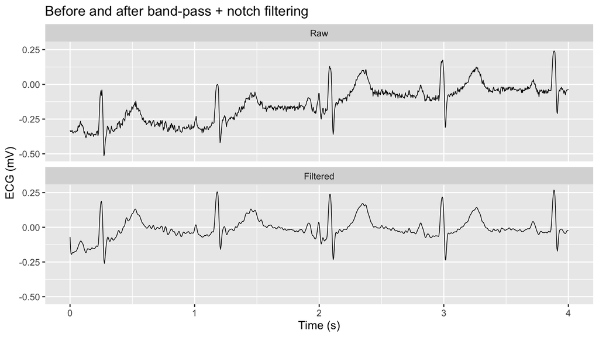

```r
fs <- 250

# keep things in conceivable "normal heart rate" range (0.5 Hz to 40 Hz) to smooth out high and low frequency noise
bandpass <- signal::butter(2, c(0.5, 40) / (fs / 2), type = "pass")

# cut out 59-61Hz signal from the electrical grid
notch    <- signal::butter(2, c(59, 61) / (fs / 2), type = "stop")

example_wave <- waveforms_train |>
  filter(rhythm == "Normal") |>
  filter(segment == first(segment))

cleaned <- example_wave |>
  mutate(
    bp_filtered = signal::filtfilt(bandpass, ecg),
    filtered    = signal::filtfilt(notch, bp_filtered)
  )

cleaned |>
  filter(time <= 4) |>
  dplyr::select(time, Raw = ecg, Filtered = filtered) |>   # dplyr::select - MASS also exports select()
  pivot_longer(c(Raw, Filtered), names_to = "stage", values_to = "ecg") |>
  mutate(stage = factor(stage, levels = c("Raw", "Filtered"))) |>
  ggplot(aes(time, ecg)) +
  geom_line(linewidth = 0.3) +
  facet_wrap(~stage, ncol = 1) +
  labs(x = "Time (s)", y = "ECG (mV)",
       title = "Before and after band-pass + notch filtering")
```

As we can see, this cleans things up a little (although isn’t perfect) so now let’s apply the **same** two filters to every waveform in both the training and test sets.

We keep the original trace as `ecg_raw` and overwrite `ecg` with the cleaned signal.

```r
clean_waveforms <- function(df) {
  df |>
    group_by(record, segment) |>
    arrange(time, .by_group = TRUE) |>
    mutate(
      ecg_raw = ecg,
      ecg     = signal::filtfilt(notch, signal::filtfilt(bandpass, ecg))
    ) |>
    ungroup()
}

waveforms_train <- clean_waveforms(waveforms_train)
waveforms_test  <- clean_waveforms(waveforms_test)

glimpse(waveforms_train)
```

```
## Rows: 20,000
## Columns: 6
## $ record  <chr> "04746", "04746", "04746", "04746", "04746", "04746", "04746",…
## $ segment <chr> "04746_AF", "04746_AF", "04746_AF", "04746_AF", "04746_AF", "0…
## $ rhythm  <fct> AF, AF, AF, AF, AF, AF, AF, AF, AF, AF, AF, AF, AF, AF, AF, AF…
## $ time    <dbl> 0.000, 0.004, 0.008, 0.012, 0.016, 0.020, 0.024, 0.028, 0.032,…
## $ ecg     <dbl> 0.07331563, 0.12585480, 0.15472892, 0.16593037, 0.17014741, 0.…
## $ ecg_raw <dbl> 0.190, 0.195, 0.200, 0.220, 0.225, 0.225, 0.240, 0.280, 0.280,…
```

**Q3 (1 marks):** As part of these filters we are dividing the sampling rate in half. What does fs/2 represent in terms of the signal we’ve captured?

**Answer Q3:** `fs/2` is the **Nyquist frequency** — the highest frequency that can be faithfully represented in a signal sampled at rate `fs`. At 250 Hz, `fs/2 = 125 Hz`. By the Nyquist theorem, to capture a frequency without aliasing (where high-frequency content folds back and appears as a false lower frequency), you must sample at least twice as fast as that frequency. Dividing filter cutoffs by `fs/2` normalises them to the range [0, 1], where 1 corresponds to the absolute maximum frequency the recording can contain. So a band-pass cutoff of `0.5 / (fs/2)` means “keep frequencies above 0.5 Hz” and `40 / (fs/2)` means “keep frequencies below 40 Hz” both well within the 125 Hz limit of this 250 Hz recording.

## 5 Exploratory Data Analysis

Remember, we only explore the **training set**!

### 5.1 Class balance and a first look

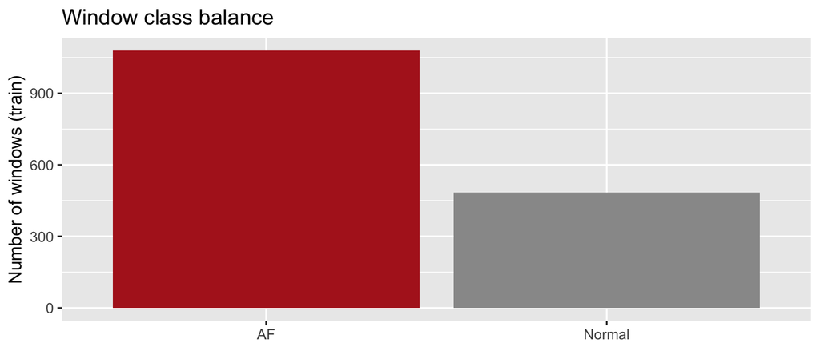

```r
rr_train |>
  distinct(record, window, rhythm) |>
  count(rhythm) |>
  ggplot(aes(rhythm, n, fill = rhythm)) +
  geom_col(show.legend = FALSE) +
  scale_fill_manual(values = c("AF" = "firebrick", "Normal" = "grey60")) +
  labs(x = NULL, y = "Number of windows (train)", title = "Window class balance")
```

A normal and an AF waveform snippet side by side - note the slightly more regular spacing in the Normal vs AF signal; the p-wave feature is less obviously different in this case:

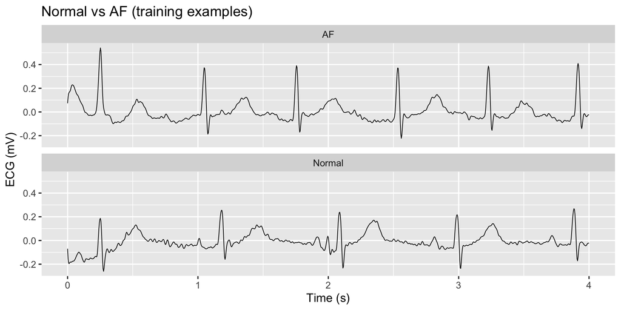

```r
waveforms_train |>
  filter(time <= 4) |>
  group_by(rhythm) |>
  filter(segment == first(segment)) |>
  ungroup() |>
  ggplot(aes(time, ecg)) +
  geom_line(linewidth = 0.3) +
  facet_wrap(~rhythm, ncol = 1) +
  labs(x = "Time (s)", y = "ECG (mV)", title = "Normal vs AF (training examples)")
```

### 5.2 Heart-rate-variability features

A few standard summaries of each window’s R-R series:

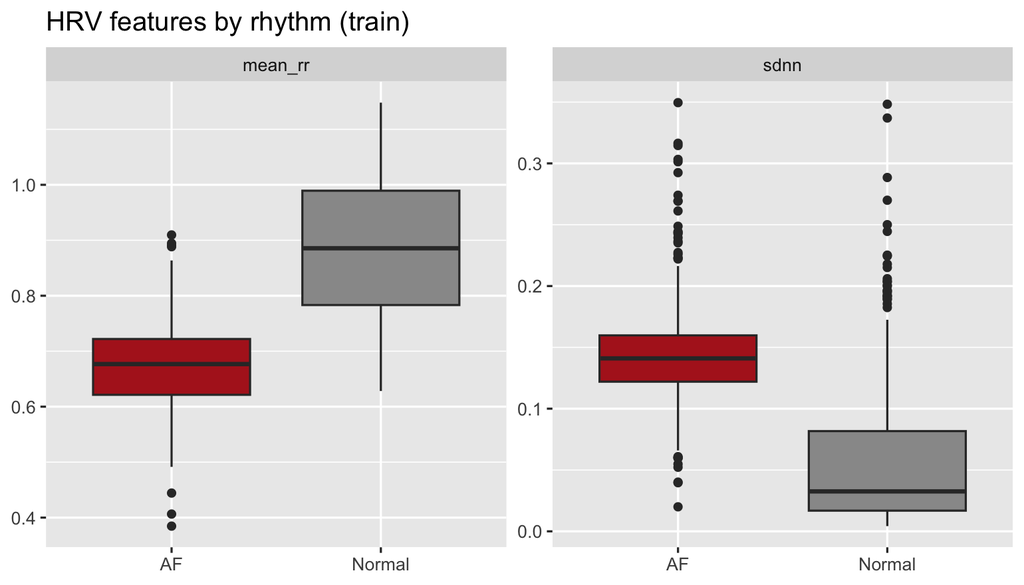

```r
window_features <- rr_train |>
  group_by(record, window, rhythm) |>
  summarise(
    mean_rr = mean(rr),                       # average interval (1 / mean_rr = mean rate)
    sdnn    = sd(rr),                          # overall variability
    .groups = "drop"
  )

window_features |>
  pivot_longer(c(mean_rr, sdnn),
               names_to = "feature", values_to = "value") |>
  ggplot(aes(rhythm, value, fill = rhythm)) +
  geom_boxplot(show.legend = FALSE) +
  facet_wrap(~feature, scales = "free_y") +
  scale_fill_manual(values = c("AF" = "firebrick", "Normal" = "grey60")) +
  labs(x = NULL, y = NULL, title = "HRV features by rhythm (train)")
```

**Q4 (2 marks):** Explain what this plot tells you about the R-R intervals in Normal vs AF samples.

**Answer Q4:** The plot shows two boxplots — `mean_rr` (average R-R interval per window) and `sdnn` (standard deviation of R-R intervals per window) — split by rhythm.

For **`sdnn`**, there is a much clearer separation: AF windows have substantially higher standard deviations than Normal windows. This directly captures the hallmark of AF — the highly irregular beat-to-beat timing. Normal sinus rhythm intervals cluster tightly around a consistent mean (low SDNN), while AF intervals jump erratically from beat to beat (high SDNN). The `sdnn` feature is therefore far more discriminative than `mean_rr` for distinguishing AF from Normal, and this irregularity is exactly what all three models in this lab aim to exploit.

## 6 Time Domain Model (ARIMA)

To detect AF with a time-domain approach we are going to work out **how predictable is the next interval given the preceding one(s) across each window?**. A regular sinus rhythm is highly predictable, so our model should be able to forecast the next intervals well; whereas an AF window is close to noise, so the forecast error is large. This means we can use our model’s **forecast error as the AF score**.

We’ll use an ARIMA model to do this. ARIMA predicts the next value from a linear combination of recent values (the AR - autoregressive part) and recent forecast errors (the MA - moving average part), after differencing the series to make it stationary (the I part).  
Specifically, we are going to use `forecast::auto.arima()` to automatically select (hyperparameter optimisation) how many previous values to use for each part of this model (also known as the “order” of the model component).

For each window we treat the R-R series as a tachogram (interval value indexed by beat number), fit ARIMA on the first 80% of beats, forecast the rest, and record the mean absolute error.

```r
arima_error <- function(window_df) {
  y   <- window_df$rr
  h   <- max(5, round(0.2 * length(y)))   # forecast horizon = last 20% of beats
  cut <- length(y) - h

  fit      <- forecast::auto.arima(y[seq_len(cut)])
  forecast <- forecast::forecast(fit, h = h)
  mean(abs(as.numeric(forecast$mean) - y[(cut + 1):length(y)]))   # forecast MAE
}
```

Here is the idea on one window of each rhythm - the red forecast tracks the regular rhythm closely but cannot keep up with AF:

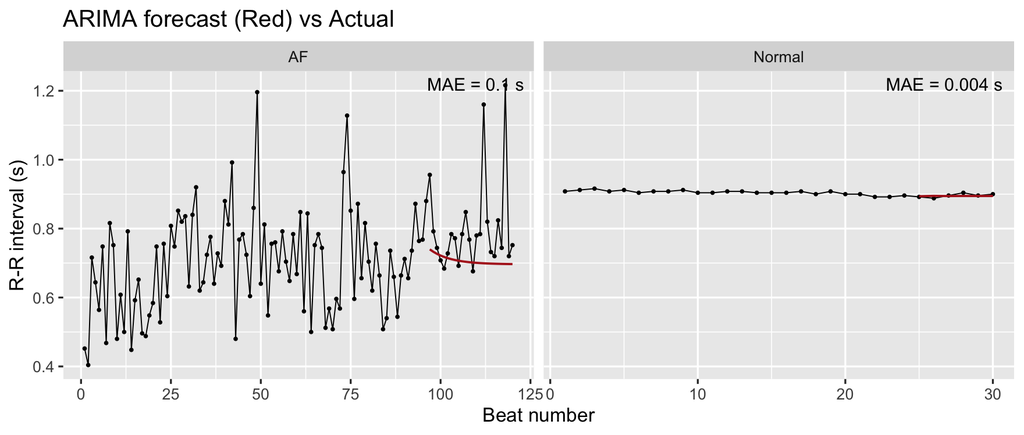

```r
demo <- rr_train |>
  group_by(rhythm) |>
  filter(window == last(window)) |>
  ungroup()

demo_forecast <- demo |>
  group_by(rhythm) |>
  group_modify(~ {
    y <- .x$rr
    h <- max(5, round(0.2 * length(y)))
    cut <- length(y) - h
    fit <- forecast::auto.arima(y[seq_len(cut)])
    fc  <- forecast::forecast(fit, h = h)
    tibble(beat     = seq_along(y),
           rr       = y,
           forecast = c(rep(NA_real_, cut), as.numeric(fc$mean)))
  }) |>
  ungroup()

# forecast error (mean absolute error over the forecast horizon) for each rhythm
demo_error <- demo_forecast |>
  filter(!is.na(forecast)) |>
  group_by(rhythm) |>
  summarise(mae = mean(abs(forecast - rr)), .groups = "drop") |>
  mutate(label = paste0("MAE = ", round(mae, 3), " s"))

ggplot(demo_forecast, aes(beat)) +
  geom_line(aes(y = rr), linewidth = 0.3) +
  geom_point(aes(y = rr), size = 0.5) +
  geom_line(aes(y = forecast), colour = "firebrick", linewidth = 0.6, na.rm = TRUE) +
  geom_text(data = demo_error, aes(x = Inf, y = Inf, label = label),
            hjust = 1.1, vjust = 1.5, size = 3.5, inherit.aes = FALSE) +
  facet_wrap(~rhythm, scales = "free_x") +
  labs(x = "Beat number", y = "R-R interval (s)",
       title = "ARIMA forecast (Red) vs Actual")
```

We build a per-window key table and a matching list of windows for the **train** and **test** sets separately. Each model below scores both sets - we look at the training scores to sanity-check that the score separates the classes, and keep the test scores untouched/unviewed for the final evaluation at the end. Now score every window. This fits one ARIMA model per window; it is cached so it only re-runs if the data changes.

```r
train_grp  <- rr_train |> group_by(record, window, rhythm)
train_keys <- group_keys(train_grp)
train_list <- group_split(train_grp)

test_grp  <- rr_test |> group_by(record, window, rhythm)
test_keys <- group_keys(test_grp)
test_list <- group_split(test_grp)

train_keys$arima_err <- map_dbl(train_list, arima_error)
test_keys$arima_err  <- map_dbl(test_list, arima_error)
```

Now we can compare the forecast error in Normal vs AF across our training set:

```r
train_keys |>
  group_by(rhythm) |>
  summarise(mean_forecast_error = mean(arima_err), .groups = "drop")
```

| rhythm | mean_forecast_error |
| --- | --- |
| AF | 0.11923653 |
| Normal | 0.04243216 |

The mean error is higher for AF, but how well does the forecast error *alone* separate AF from Normal? We are treating `arima_err` directly as an AF score (larger = more AF-like). To make a prediction of AF vs Normal we to pick a threshold score i.e., if `arima_err` is greater than threshold we predict AF and below Normal.

To do this we look at the **ROC curve**, which traces sensitivity against 1 - specificity as we sweep the detection threshold across every value of `arima_err`. We then pick the threshold value that maximises the Area Under the Curve (or **AUC**).

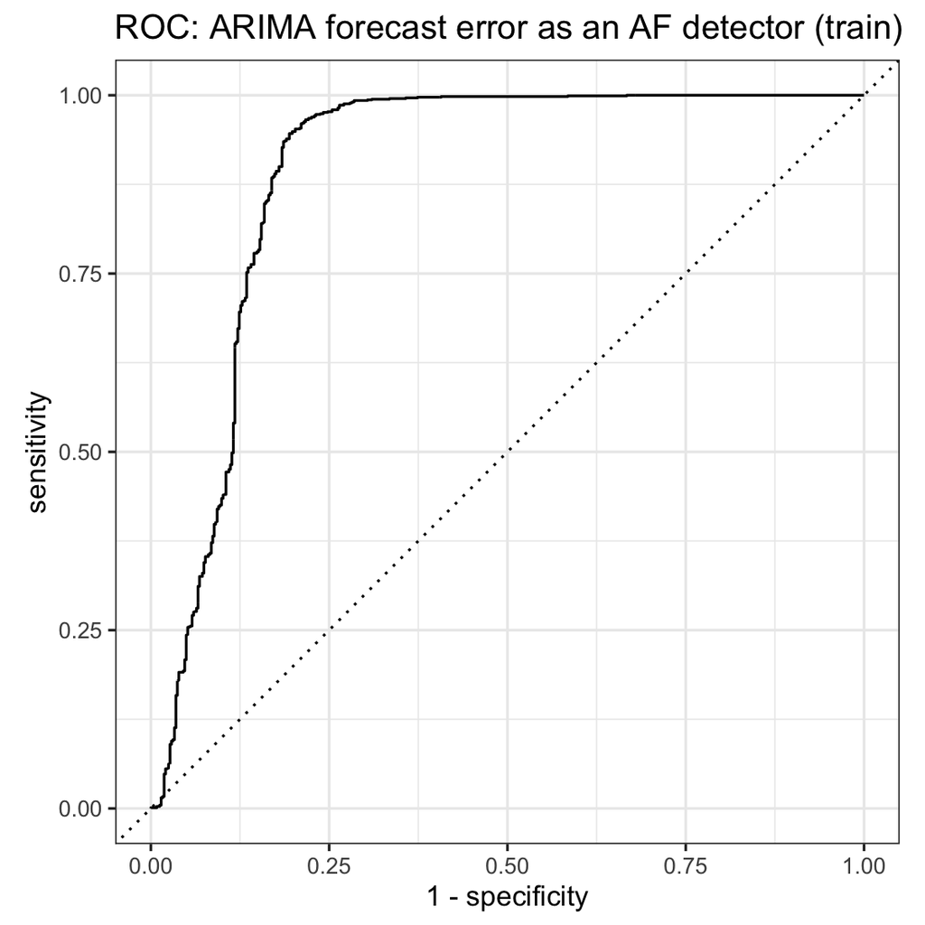

```r
train_keys |>
  roc_curve(truth = rhythm, arima_err, event_level = "first") |>
  autoplot() +
  labs(title = "ROC: ARIMA forecast error as an AF detector (train)")
```

```r
train_keys |>
  roc_auc(truth = rhythm, arima_err, event_level = "first")
```

| .metric | .estimator | .estimate |
| --- | --- | --- |
| roc_auc | binary | 0.8937674 |

**Q5 (1 marks):** What other type of curve could we use to select the threshold? (Hint: think back to earlier labs)

**Answer Q5:** We could use a **precision-recall (PR) curve**, which plots precision (positive predictive value) against recall (sensitivity) across all possible thresholds. Unlike the ROC curve, the PR curve is more informative under class imbalance. It directly shows the trade-off between how many predicted AF cases are correct (precision) and how many true AF cases are caught (recall). The threshold that maximises the **F1 score** (the harmonic mean of precision and recall) is a common operating point choice from the PR curve.

## 7 Frequency Domain

The frequency-domain formulation we are going to use is **does AF and Normal signals have distinguishable amounts of different frequencies in their signals?**

We can infer the frequency distribution of a signal using the Fourier transform (base R’s `fft()`). A regular rhythm varies slowly (its R-R series wanders gently with breathing), so we expect its energy sits at *low* frequencies in a single concentrated peak. AF jumps from beat to beat, so its energy spreads out and up into *higher* frequencies. Rather than collapse this into one hand-picked score, we summarise each window’s spectrum with **a handful of frequency-space features** and then let a **logistic regression** learn how to weight them.

For each window we compute four interpretable frequency statistics:

- `hf_frac` - fraction of power in the **upper half** of the band (AF pushes power up here),
- `spectral_centroid` - the power-weighted **mean frequency bin** (the spectrum’s “centre of mass”; higher for AF),
- `spectral_entropy` - how **spread out / noisy** the spectrum is, normalised to `[0, 1]` (a flat, broadband AF spectrum scores near 1; a single sharp peak scores near 0),
- `peak_frac` - the share of power in the **single biggest bin** (a regular rhythm concentrates power in one peak, so this is high for Normal).

```r
freq_features <- function(rr) {
  x     <- rr - mean(rr)                       # remove the DC offset
  n     <- length(x)
  power <- (Mod(fft(x))^2)[2:floor(n / 2)]     # one-sided power, dropping the DC term
  if (sum(power) == 0) {
    return(tibble(hf_frac = 0, spectral_centroid = 0,
                  spectral_entropy = 0, peak_frac = 0))
  }
  k    <- length(power)
  bins <- seq_len(k)
  p    <- power / sum(power)                    # spectrum as a probability distribution

  tibble(
    hf_frac           = sum(power[round(k / 2):k]) / sum(power),
    spectral_centroid = sum(bins * p),
    spectral_entropy  = -sum(p * log(p + 1e-12)) / log(k),
    peak_frac         = max(p)
  )
}

# attach the features to each window's key table. Assigning by column name
# overwrites any existing copies, so re-running this block never duplicates or
# mangles column names (unlike bind_cols).
train_feats <- map_dfr(train_list, ~ freq_features(.x$rr))
test_feats  <- map_dfr(test_list,  ~ freq_features(.x$rr))

train_keys[names(train_feats)] <- train_feats
test_keys[names(test_feats)]   <- test_feats

train_keys |>
  group_by(rhythm) |>
  summarise(across(c(hf_frac, spectral_centroid, spectral_entropy, peak_frac), mean),
            .groups = "drop")
```

| rhythm | hf_frac | spectral_centroid | spectral_entropy | peak_frac |
| --- | --- | --- | --- | --- |
| AF | 0.5391871 | 7.219669 | 0.8526721 | 0.2336264 |
| Normal | 0.4273155 | 5.785641 | 0.7153538 | 0.3800946 |

Now we fit a simple logistic regression that predicts the probability a window is **AF** from those four features, using the **training** windows only. The fitted probability is the frequency model’s AF score (`freq_prob`).

```r
freq_model <- glm(
  (rhythm == "AF") ~ hf_frac + spectral_centroid + spectral_entropy + peak_frac,
  family = binomial,
  data   = train_keys
)

summary(freq_model)
```

```
##
## Call:
## glm(formula = (rhythm == "AF") ~ hf_frac + spectral_centroid +
##     spectral_entropy + peak_frac, family = binomial, data = train_keys)
##
## Coefficients:
##                   Estimate Std. Error z value Pr(>|z|)
## (Intercept)        -9.9435     1.8149  -5.479 4.28e-08 ***
## hf_frac            -5.3487     0.9058  -5.905 3.53e-09 ***
## spectral_centroid   0.6396     0.1053   6.073 1.26e-09 ***
## spectral_entropy   11.1099     1.7850   6.224 4.84e-10 ***
## peak_frac           0.6069     1.4757   0.411    0.681
## ---
## Signif. codes:  0 '***' 0.001 '**' 0.01 '*' 0.05 '.' 0.1 ' ' 1
##
## (Dispersion parameter for binomial family taken to be 1)
##
##     Null deviance: 1934.5  on 1562  degrees of freedom
## Residual deviance: 1473.2  on 1558  degrees of freedom
## AIC: 1483.2
##
## Number of Fisher Scoring iterations: 5
```

```r
# predicted probability of AF for every window
train_keys$freq_prob <- predict(freq_model, type = "response")
test_keys$freq_prob  <- predict(freq_model, newdata = test_keys, type = "response")
```

**Q6 (2 marks)** Based on the output from summary above which frequency-based features are the best predictors of AF in this dataset? Does this match our hypotheses (above) for what each of these features will capture?

Similarly to the time-based model above, we have to pick a threshold on the logistic regression output to decide when to make a prediction of AF. We can sweep possible thresholds from 0 to 1 to again trace out the **ROC curve**. Each point is one cut-off for calling a window AF; the dashed diagonal is chance, and the more the curve bows towards the top-left the better the model separates AF from Normal:

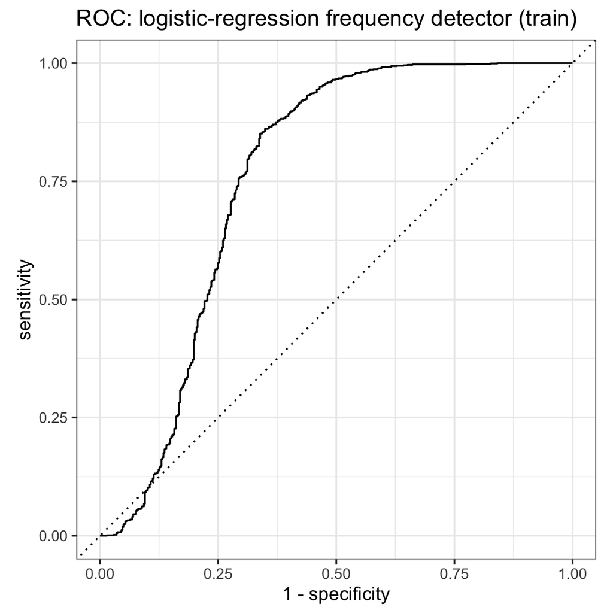

```r
train_keys |>
  roc_curve(truth = rhythm, freq_prob, event_level = "first") |>
  autoplot() +
  labs(title = "ROC: logistic-regression frequency detector (train)")
```

```r
train_keys |>
  roc_auc(truth = rhythm, freq_prob, event_level = "first")
```

| .metric | .estimator | .estimate |
| --- | --- | --- |
| roc_auc | binary | 0.7589615 |

**Q7 (1 mark)**: What does it mean for the ROC curve to be below the dotted line?

**Answer Q7:** The dotted diagonal line on a ROC curve represents the performance of a **random classifier** (AUC = 0.5) — one that assigns scores with no relationship to the true class. A curve that falls *below* this line means the model is performing **worse than random chance**: it is systematically assigning higher scores to Normal windows and lower scores to AF windows, i.e., the scoring direction is inverted. This does not mean the model has learned nothing. it has actually learned a real signal, but got the direction backwards. Flipping all predictions (predicting AF when the score is low and Normal when it is high) would produce a curve that mirrors above the diagonal and would perform better than random.

## 8 State Space (Hidden Markov Model)

The state-space model formulation is: **what sequence of hidden states best explains the observed intervals?** where the rhythm moves between unobserved states that each emit specific intervals with different probabilities.

Rather than discretising each interval into a symbol, we model the **interval values directly** as continuous series of emitted values. We fit a two-state HMM on all the training windows using `depmixS4`. With two hidden states the model tends to discover one “regular” state (intervals tightly clustered around a mean) and one “irregular” state (a broad, high-variance distribution). Crucially we never show it the AF/Normal labels - the states in this case are learned purely from the distribution of R-R intervals.

```r
# concatenate the training windows into one series, recording each window's length
# so depmixS4 treats the windows as separate sequences (the ntimes argument)
train_seq    <- bind_rows(train_list)
ntimes_train <- map_int(train_list, nrow)

hmm_spec <- depmix(rr ~ 1, data = train_seq, nstates = 2,
                   family = gaussian(), ntimes = ntimes_train)
hmm_fit  <- fit(hmm_spec, verbose = FALSE)
```

```
## converged at iteration 52 with logLik: 23365.62
```

```r
summary(hmm_fit)
```

```
## Initial state probabilities model
##   pr1   pr2
## 0.167 0.833
##
## Transition matrix
##         toS1  toS2
## fromS1 0.990 0.010
## fromS2 0.002 0.998
##
## Response parameters
## Resp 1 : gaussian
##     Re1.(Intercept) Re1.sd
## St1           0.994  0.085
## St2           0.689  0.158
```

The two states differ in their emission distributions - one has a much larger standard deviation (the AF-like, irregular state). We use the **training labels** only to decide *which* hidden state that is: the state that accounts for most of the beats occurring in AF windows.

```r
train_states <- posterior(hmm_fit, type = "viterbi")$state   # decoded state per beat

af_state <- tibble(rhythm = train_seq$rhythm, state = train_states) |>
  count(state, rhythm) |>
  group_by(state) |>
  summarise(af_frac = sum(n[rhythm == "AF"]) / sum(n), .groups = "drop") |>
  slice_max(af_frac, n = 1, with_ties = FALSE) |>
  pull(state)
```

Now to label a whole **window** we infer the underlying hidden states across the window and look at how much of it sits in the AF state. The *fraction* of a window’s beats in the AF state is a natural continuous AF score; a simple majority vote would threshold it at 0.5, but below we instead fit the best threshold from an ROC curve (below).

For new (test) data, `depmixS4` predicts by building a model with the same structure, copying the fitted parameters into it, and decoding - it does not re-estimate anything:

```r
# Viterbi-decode a list of windows under an already-fitted model
decode_states <- function(window_list, fitted) {
  seq_df <- bind_rows(window_list)
  spec   <- depmix(rr ~ 1, data = seq_df, nstates = 2,
                   family = gaussian(), ntimes = map_int(window_list, nrow))
  spec   <- setpars(spec, getpars(fitted))   # reuse the trained parameters
  posterior(spec, type = "viterbi")$state
}

# fraction of each window's beats that fall in the AF state
af_fraction <- function(states, window_list) {
  idx <- rep(seq_along(window_list), map_int(window_list, nrow))
  as.numeric(tapply(states == af_state, idx, mean))
}

train_keys$hmm_score <- af_fraction(train_states, train_list)
test_keys$hmm_score  <- af_fraction(decode_states(test_list, hmm_fit), test_list)
```

Now let’s fit the threshold we are going to use to determine how much of a window should be in the AF state to classify the window as AF.

```r
roc_hmm <- train_keys |>
  roc_curve(truth = rhythm, hmm_score, event_level = "first")

hmm_threshold <- roc_hmm |>
  mutate(youden = sensitivity + specificity - 1) |>
  slice_max(youden, n = 1, with_ties = FALSE)

hmm_threshold
```

| .threshold | specificity | sensitivity | youden |
| --- | --- | --- | --- |
| 0.7333333 | 0.5557851 | 0.9990732 | 0.5548583 |

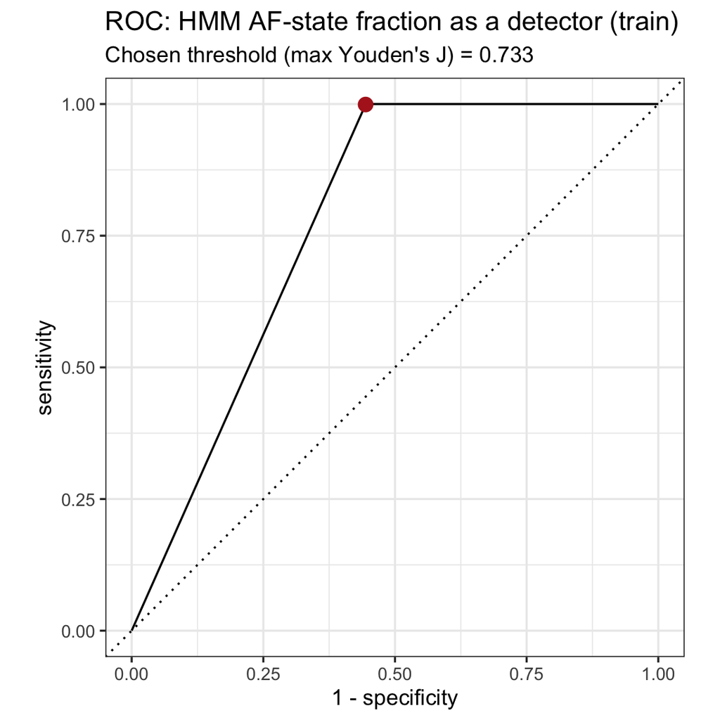

```r
autoplot(roc_hmm) +
  geom_point(data = hmm_threshold,
             aes(x = 1 - specificity, y = sensitivity),
             colour = "firebrick", size = 3) +
  labs(title = "ROC: HMM AF-state fraction as a detector (train)",
       subtitle = paste0("Chosen threshold (max Youden's J) = ",
                         round(hmm_threshold$.threshold, 3)))
```

We then label every window by comparing its AF-state fraction to that fitted threshold:

```r
label_hmm <- function(df) {
  df |> mutate(hmm_pred = factor(if_else(hmm_score >= hmm_threshold$.threshold,
                                         "AF", "Normal"),
                                 levels = c("AF", "Normal")))
}
train_keys <- label_hmm(train_keys)
test_keys  <- label_hmm(test_keys)
```

How well does that rule separate the rhythms on the training windows?

```r
train_keys |>
  conf_mat(truth = rhythm, estimate = hmm_pred)
```

```
##           Truth
## Prediction   AF Normal
##     AF     1078    215
##     Normal    1    269
```

**Q8 (2 marks):** In this HMM, what is *observed* and what is *hidden*?

## 9 Comparing the Three Detectors

Each model gives every window a score where larger means more AF-like. To compare them fairly we rescale each score to `[0, 1]` (so they share an axis) and evaluate on the **held-out test records**. The **ROC curve** and its **AUC** summarise how well each score separates AF from normal across all possible cut-offs - the same yardstick both papers report.

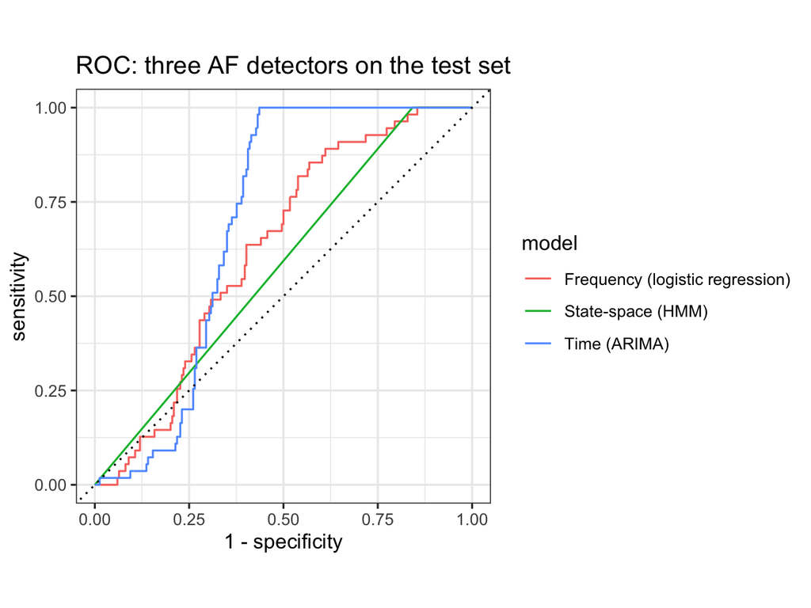

```r
test_scored <- test_keys |>
  mutate(across(c(arima_err, freq_prob, hmm_score), rescale)) |>   # higher = more AF
  pivot_longer(c(arima_err, freq_prob, hmm_score),
               names_to = "model", values_to = "score") |>
  mutate(
    model = recode(model,
                   arima_err = "Time (ARIMA)",
                   freq_prob = "Frequency (logistic regression)",
                   hmm_score = "State-space (HMM)"),
    truth = factor(rhythm, levels = c("AF", "Normal"))
  )

# ROC curves, all three models on one set of axes
test_scored |>
  group_by(model) |>
  roc_curve(truth, score, event_level = "first") |>
  autoplot() +
  labs(title = "ROC: three AF detectors on the test set")
```

```r
test_scored |>
  group_by(model) |>
  roc_auc(truth, score, event_level = "first") |>
  dplyr::select(model, .estimate) |>   # dplyr::select - MASS (via depmixS4) also exports select()
  arrange(desc(.estimate))
```

| model | .estimate |
| --- | --- |
| Time (ARIMA) | 0.6920746 |
| Frequency (logistic regression) | 0.6254856 |
| State-space (HMM) | 0.5790598 |

**Q9 (2 marks):** How do these models compare to one another?

**Q10 (3 marks):** Suggest a way we could improve each of these models performance and suggest at least 3 additional analyses that it would be a good idea to perform before trying to use these in the real-world.

**Answer Q10:**

**Model improvements:**

- **Time-domain (ARIMA):** Rather than collapsing a whole window to a single forecast MAE, we could extract richer time-domain HRV features per window such as RMSSD (root mean square of successive differences), pNN50 (proportion of successive intervals differing by more than 50 ms), and the coefficient of variation and feed them into a logistic regression or random forest. These are established clinical HRV metrics that more completely characterise beat-to-beat irregularity than ARIMA forecast error alone.
- **Frequency-domain (logistic regression):** The current features are all derived from the R-R interval tachogram. A direct improvement would be to compute frequency features from the **raw ECG waveform** (using `waveforms`) rather than the R-R series, which would capture the loss of the P wave a hallmark of AF alongside spectral irregularity. Additionally, replacing logistic regression with a more powerful classifier (e.g., random forest or gradient boosted trees) would allow non-linear interactions between features to be exploited.
- **State-space (HMM):** The current model uses only two states and a single observed variable (`rr`). Performance could be improved by increasing the number of states to capture transitional rhythms, or by building a **multivariate HMM** that jointly models R-R intervals alongside additional features (e.g., QRS duration or amplitude derived from the waveform). A deep learning alternative such as an LSTM, which models long-range sequential dependencies, would likely outperform a Gaussian HMM on longer recordings.

**Additional real-world analyses:**

1. **External validation on an independent dataset.** All three models were trained and tested on a single database (MIT-BIH AFIB). Before clinical use, they should be evaluated on data from a different institution, country, or device type to assess whether performance generalises beyond the specific recording conditions, patient population, and annotation protocol of this dataset.
2. **Subgroup analysis.** AF presentation and ECG morphology can differ by age, sex, and comorbidities (e.g., heart failure, diabetes). Performance should be broken down by patient subgroup to check that no group is systematically disadvantaged a model with strong overall AUC can still perform poorly on elderly patients or those with co-existing arrhythmias.
3. **Clinical operating point and calibration analysis.** AUC summarises performance across all thresholds but clinicians need to operate at one specific threshold. A full sensitivity/specificity analysis at clinically meaningful operating points (e.g., targeting ≥ 90% sensitivity for a screening tool) is needed, along with calibration curves to verify that predicted probabilities actually reflect true AF likelihood a model can have high AUC but poorly calibrated probabilities, which matters if the score is used to triage urgency of referral.